# Reproducible Research: Peer Assessment 1

Sunday, November 16, 2014

## Loading and preprocessing the data

1. Load the data (i.e. read.csv())

```r
if(!file.exists("activity.csv")) {unzip("activity.zip")}
Act <- read.csv("activity.csv")
```

2. Process/transform the data (if necessary) into a format suitable for your analysis

```r
Act$date<-as.Date(Act$date, format = '%Y-%m-%d')
```

## What is mean total number of steps taken per day?

1. Make a histogram of the total number of steps taken each day

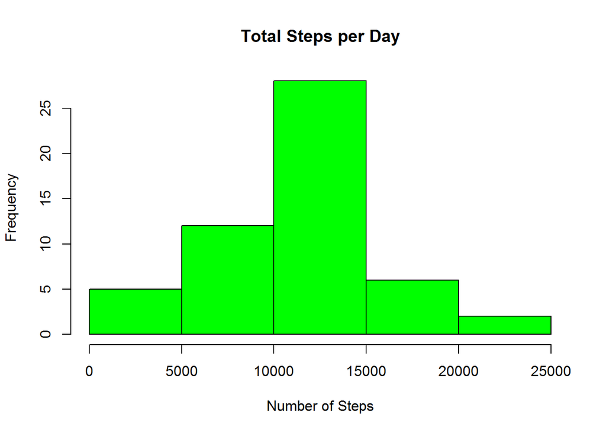

```r
# Note: ignore the missing values in the dataset.
# Calculate Total Steps by Date (Aggregate)
TotAct <- aggregate(steps~date, Act,sum, na.rm=TRUE)
hist(TotAct$steps, xlab="Number of Steps", main="Total Steps per Day", col="green")
```

```r
# Calculate Mean and Median
DailyMean <- mean(TotAct$steps, na.rm=TRUE)
DailyMedian <- median(TotAct$steps, na.rm=TRUE)
```

## What is the average daily activity pattern?

1. Make a time series plot (i.e. type = “l”) of the 5-minute interval (x-axis) and the average number of steps taken, averaged across all days (y-axis)

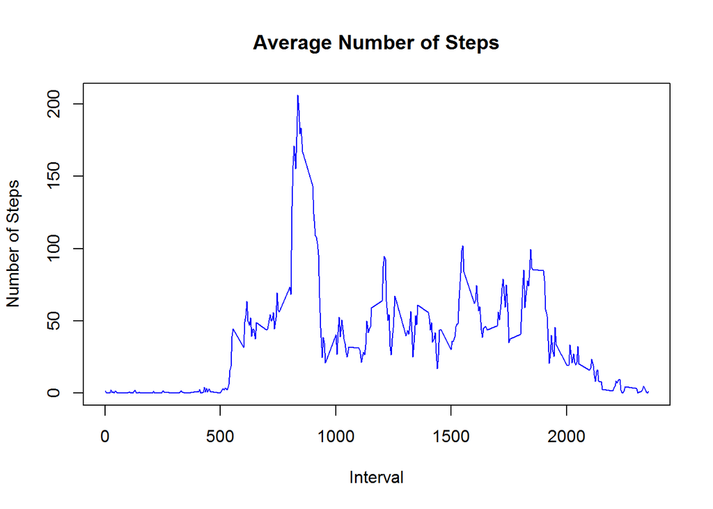

```r
IntAct <- aggregate(steps ~ interval, Act, mean)
plot(IntAct$interval,IntAct$steps, type="l", col="blue", xlab="Interval", ylab="Number of Steps",main="Average Number of Steps")
```

2. Which 5-minute interval, on average across all the days in the dataset, contains the maximum number of steps?

```r
MaxInt <- IntAct[which.max(IntAct$steps),1]
```

The 5-minute interval which contains the maximum number of steps is **835**

## Imputing missing values

1. Calculate and report the total number of missing values in the dataset (i.e. the total number of rows with NAs)

```r
# get rows with NA's
Act_NA <- Act[!complete.cases(Act),]
```

The Total number of rows with NAs is **2304**

2. Create a new dataset that is equal to the original dataset but with the missing data filled in.

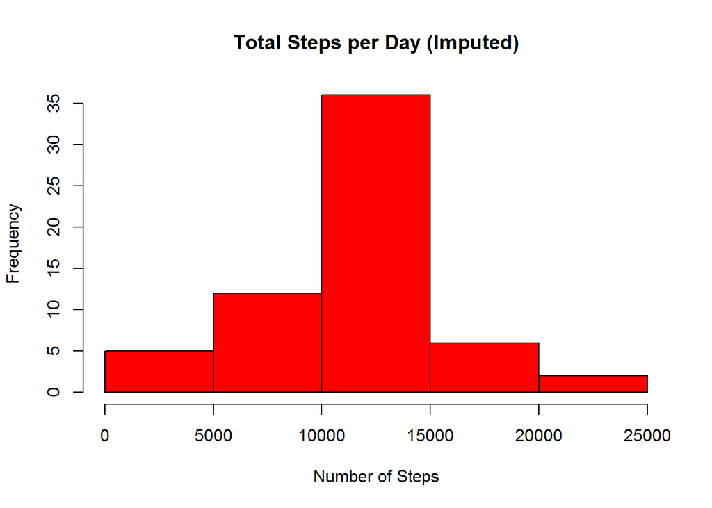

```r
# perform the imputation
for (i in 1:nrow(Act)){
    if (is.na(Act$steps[i])){
        IntVal <- Act$interval[i]
        row <- which(IntAct$interval == IntVal)
        StepVal <- IntAct$steps[row]
        Act$steps[i] <- StepVal
    }
}

# aggregate steps as per date to get total number of steps in a day
ActImp <- aggregate(steps ~ date, Act, sum)

# create histogram of total number of steps in a day
hist(ActImp$steps, xlab="Number of Steps", main="Total Steps per Day (Imputed)", col="red")
```

3. Calculate and report the mean and median total number of steps taken per day. Do these values differ from the estimates from the first part of the assignment? What is the impact of imputing missing data on the estimates of the total daily number of steps?

```r
# Calculate the Mean and Median for the Imputed Values
DailyMeanImp <- mean(ActImp$steps, na.rm=TRUE)
DailyMedianImp <- median(ActImp$steps, na.rm=TRUE)
```

There is no difference between the Means of both the datasets. But there is a slight difference between the Medians.

## Are there differences in activity patterns between weekdays and weekends?

```r
# Add a column wday
Act$wday <- ifelse(weekdays(Act$date) %in%  c("Saturday", "Sunday"),'weekend','weekday')

# Convert wday as Factor
Act$wday <- as.factor(Act$wday)

# Aggregate
ActImp2 <- aggregate(steps ~ interval+wday, Act, mean)
```

2. Make a panel plot containing a time series plot (i.e. type = “l”) of the 5-minute interval (x-axis) and the average number of steps taken, averaged across all weekday days or weekend days (y-axis).

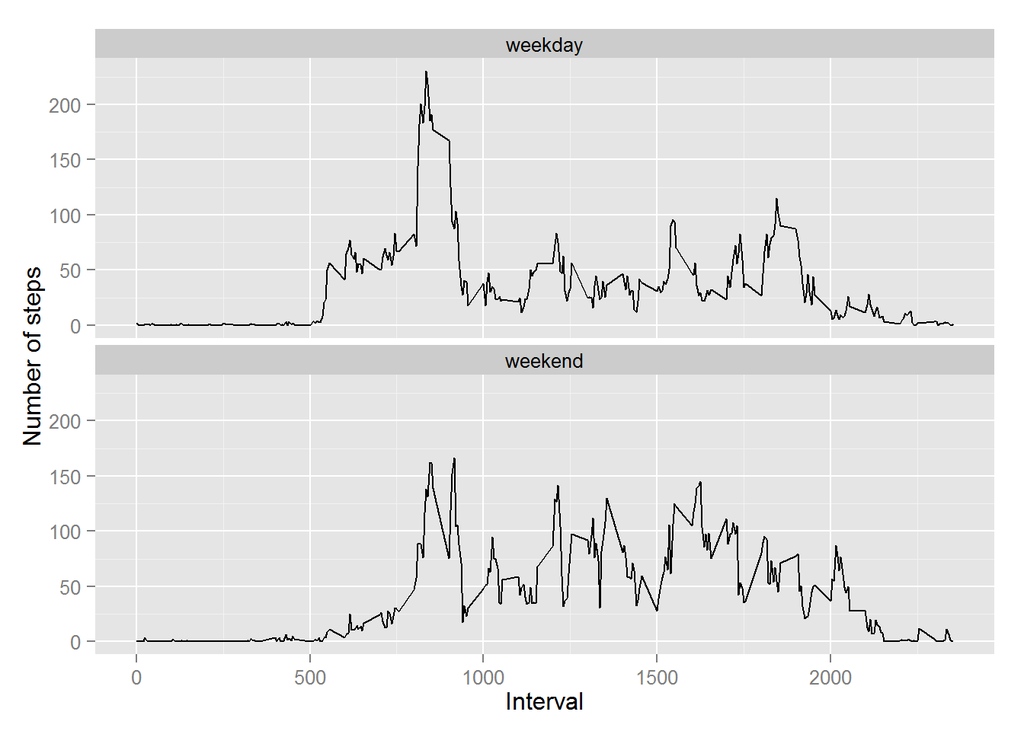

```r
library(ggplot2)

qplot(interval, steps, data=ActImp2, geom=c("line"), xlab="Interval",
      ylab="Number of steps") + facet_wrap(~ wday, ncol=1, )
```